# Machine Learning Model For Predicting Customer Behavior

**Author:** Kyle Arick Kassen  
**Date:** November 21, 2021 — November 27, 2021  
**Dataset:** https://www.kaggle.com/mojtaba142/hotel-booking  
**Business Objective:** *Predict Customer Propensity to Cancel an Order*

## Introduction

Thank you for this opportunity to demonstrate my technical skills, thought process, creativity, and talent.  
The following notebook reflects a slightly modified version of my framework for Data Science workflow. Those Steps within my framework that I considered to be important but not mandatory are mentioned with brief remarks. I have included comments within my code as well as html sections for added structure and explanation. As every Data Scientist knows, the actual process is much messier than the final product; such is the nature of this notebook.  
**A brief roadmap for what lies ahead:**  
1) Import Statements  
2) Data Retrieval and Review  
3) Summary Statistics  
4) Data Cleaning  
5) Training and Testing Datasets  
6) Pearson's Correlation Coefficient  
7) Machine Learning Model  
8) Business Insights and Recommendations

*y* = is_canceled  
*x* = features [x0,x1,x2,...,xn] that might be important in predicting cancellation

## Import Statements

```python
#import statements for retrieving relevant libraries and associated methods
import pandas as pd
import seaborn as sns
import matplotlib.pyplot as plt
import sklearn as sk
```

## Data Retrieval and Review

Data retrieval and review is fairly straightforward in this case but remains crucial; especially in those cases where data retrieval pipelines become more complicated. It's important that we always verify our data is retrieved properly by calling the data frame. In more complex circumstances, I might consider making the intake mechanism more robust by using a function that captures a generic path so that 'any' file could be loaded. This is also a good opportunity to start getting familiar with our dataset.  
**I usually start by trying to classify the variables into subsets, such as:**  
1) Numerical Continuous  
2) Numerical Discrete  
3) Categorical Unordered  
4) Categorical Ordered  
5) Dates or Times  
6) Text  
I then note the number of rows and columns in the data frame.  
I am reviewing the data types of our features and noting missing values in the rows.  
Ultimately, all of these observations become important to cleaning the dataset.  
I have observed that country, agent, company, and children have missing row values.

```python
#Retrieving the dataset and storing data into a data frame
df = pd.read_csv('data_.csv')


#Quality check: Ensuring data was properly retrieved and stored in the data frame
#We could also use df.head() to view first five rows and df.tail() to view last five rows
df
```

|  | hotel | is_canceled | lead_time | arrival_date_year | arrival_date_month | arrival_date_week_number | arrival_date_day_of_month | stays_in_weekend_nights | stays_in_week_nights | adults | ... | customer_type | adr | required_car_parking_spaces | total_of_special_requests | reservation_status | reservation_status_date | name | email | phone-number | credit_card |
| --- | --- | --- | --- | --- | --- | --- | --- | --- | --- | --- | --- | --- | --- | --- | --- | --- | --- | --- | --- | --- | --- |
| 0 | Resort Hotel | 0 | 342 | 2015 | July | 27 | 1 | 0 | 0 | 2 | ... | Transient | 0.00 | 0 | 0 | Check-Out | 2015-07-01 | Ernest Barnes | Ernest.Barnes31@outlook.com | 669-792-1661 | ************4322 |
| 1 | Resort Hotel | 0 | 737 | 2015 | July | 27 | 1 | 0 | 0 | 2 | ... | Transient | 0.00 | 0 | 0 | Check-Out | 2015-07-01 | Andrea Baker | Andrea_Baker94@aol.com | 858-637-6955 | ************9157 |
| 2 | Resort Hotel | 0 | 7 | 2015 | July | 27 | 1 | 0 | 1 | 1 | ... | Transient | 75.00 | 0 | 0 | Check-Out | 2015-07-02 | Rebecca Parker | Rebecca_Parker@comcast.net | 652-885-2745 | ************3734 |
| 3 | Resort Hotel | 0 | 13 | 2015 | July | 27 | 1 | 0 | 1 | 1 | ... | Transient | 75.00 | 0 | 0 | Check-Out | 2015-07-02 | Laura Murray | Laura_M@gmail.com | 364-656-8427 | ************5677 |
| 4 | Resort Hotel | 0 | 14 | 2015 | July | 27 | 1 | 0 | 2 | 2 | ... | Transient | 98.00 | 0 | 1 | Check-Out | 2015-07-03 | Linda Hines | LHines@verizon.com | 713-226-5883 | ************5498 |
| ... | ... | ... | ... | ... | ... | ... | ... | ... | ... | ... | ... | ... | ... | ... | ... | ... | ... | ... | ... | ... | ... |
| 119385 | City Hotel | 0 | 23 | 2017 | August | 35 | 30 | 2 | 5 | 2 | ... | Transient | 96.14 | 0 | 0 | Check-Out | 2017-09-06 | Claudia Johnson | Claudia.J@yahoo.com | 403-092-5582 | ************8647 |
| 119386 | City Hotel | 0 | 102 | 2017 | August | 35 | 31 | 2 | 5 | 3 | ... | Transient | 225.43 | 0 | 2 | Check-Out | 2017-09-07 | Wesley Aguilar | WAguilar@xfinity.com | 238-763-0612 | ************4333 |
| 119387 | City Hotel | 0 | 34 | 2017 | August | 35 | 31 | 2 | 5 | 2 | ... | Transient | 157.71 | 0 | 4 | Check-Out | 2017-09-07 | Mary Morales | Mary_Morales@hotmail.com | 395-518-4100 | ************1821 |
| 119388 | City Hotel | 0 | 109 | 2017 | August | 35 | 31 | 2 | 5 | 2 | ... | Transient | 104.40 | 0 | 0 | Check-Out | 2017-09-07 | Caroline Conley MD | MD_Caroline@comcast.net | 531-528-1017 | ************7860 |
| 119389 | City Hotel | 0 | 205 | 2017 | August | 35 | 29 | 2 | 7 | 2 | ... | Transient | 151.20 | 0 | 2 | Check-Out | 2017-09-07 | Ariana Michael | Ariana_M@xfinity.com | 422-804-6403 | ************4482 |

119390 rows × 36 columns

```python
#Our dataset has 119,390 rows and 36 columns
df.shape
```

```
(119390, 36)
```

```python
#Reviewing the data types of our columns
#looking for instances of less than our total number of rows
df.info()
```

```
<class 'pandas.core.frame.DataFrame'>
RangeIndex: 119390 entries, 0 to 119389
Data columns (total 36 columns):
 #   Column                          Non-Null Count   Dtype
---  ------                          --------------   -----
 0   hotel                           119390 non-null  object
 1   is_canceled                     119390 non-null  int64
 2   lead_time                       119390 non-null  int64
 3   arrival_date_year               119390 non-null  int64
 4   arrival_date_month              119390 non-null  object
 5   arrival_date_week_number        119390 non-null  int64
 6   arrival_date_day_of_month       119390 non-null  int64
 7   stays_in_weekend_nights         119390 non-null  int64
 8   stays_in_week_nights            119390 non-null  int64
 9   adults                          119390 non-null  int64
```

[output cut: 28 more lines]

## Summary Statistics

At this point in the process, I am still getting familiar with our dataset.  
In reviewing the summary statistics, I am considering the amount of variance as measured by the standard deviation, minimum values and maximum values for anomalies, visualizing the distributions for numerical features, and visualizing the counts for categorical features.  
Again, all of these observations become important to cleaning the dataset.  
I have noted a negative value for the average daily rate feature, a large value for the average daily rate feature, a booking for zero adults, and a large value for the lead time feature.

```python
#Summary statistics for our dataset
df.describe()
```

|  | is_canceled | lead_time | arrival_date_year | arrival_date_week_number | arrival_date_day_of_month | stays_in_weekend_nights | stays_in_week_nights | adults | children | babies | is_repeated_guest | previous_cancellations | previous_bookings_not_canceled | booking_changes | agent | company | days_in_waiting_list | adr | required_car_parking_spaces | total_of_special_requests |
| --- | --- | --- | --- | --- | --- | --- | --- | --- | --- | --- | --- | --- | --- | --- | --- | --- | --- | --- | --- | --- |
| count | 119390.000000 | 119390.000000 | 119390.000000 | 119390.000000 | 119390.000000 | 119390.000000 | 119390.000000 | 119390.000000 | 119386.000000 | 119390.000000 | 119390.000000 | 119390.000000 | 119390.000000 | 119390.000000 | 103050.000000 | 6797.000000 | 119390.000000 | 119390.000000 | 119390.000000 | 119390.000000 |
| mean | 0.370416 | 104.011416 | 2016.156554 | 27.165173 | 15.798241 | 0.927599 | 2.500302 | 1.856403 | 0.103890 | 0.007949 | 0.031912 | 0.087118 | 0.137097 | 0.221124 | 86.693382 | 189.266735 | 2.321149 | 101.831122 | 0.062518 | 0.571363 |
| std | 0.482918 | 106.863097 | 0.707476 | 13.605138 | 8.780829 | 0.998613 | 1.908286 | 0.579261 | 0.398561 | 0.097436 | 0.175767 | 0.844336 | 1.497437 | 0.652306 | 110.774548 | 131.655015 | 17.594721 | 50.535790 | 0.245291 | 0.792798 |
| min | 0.000000 | 0.000000 | 2015.000000 | 1.000000 | 1.000000 | 0.000000 | 0.000000 | 0.000000 | 0.000000 | 0.000000 | 0.000000 | 0.000000 | 0.000000 | 0.000000 | 1.000000 | 6.000000 | 0.000000 | -6.380000 | 0.000000 | 0.000000 |
| 25% | 0.000000 | 18.000000 | 2016.000000 | 16.000000 | 8.000000 | 0.000000 | 1.000000 | 2.000000 | 0.000000 | 0.000000 | 0.000000 | 0.000000 | 0.000000 | 0.000000 | 9.000000 | 62.000000 | 0.000000 | 69.290000 | 0.000000 | 0.000000 |
| 50% | 0.000000 | 69.000000 | 2016.000000 | 28.000000 | 16.000000 | 1.000000 | 2.000000 | 2.000000 | 0.000000 | 0.000000 | 0.000000 | 0.000000 | 0.000000 | 0.000000 | 14.000000 | 179.000000 | 0.000000 | 94.575000 | 0.000000 | 0.000000 |
| 75% | 1.000000 | 160.000000 | 2017.000000 | 38.000000 | 23.000000 | 2.000000 | 3.000000 | 2.000000 | 0.000000 | 0.000000 | 0.000000 | 0.000000 | 0.000000 | 0.000000 | 229.000000 | 270.000000 | 0.000000 | 126.000000 | 0.000000 | 1.000000 |
| max | 1.000000 | 737.000000 | 2017.000000 | 53.000000 | 31.000000 | 19.000000 | 50.000000 | 55.000000 | 10.000000 | 10.000000 | 1.000000 | 26.000000 | 72.000000 | 21.000000 | 535.000000 | 543.000000 | 391.000000 | 5400.000000 | 8.000000 | 5.000000 |

```python
#Here is where I would normally do a more thourough (pre data cleaning) visual data exploration.
#I have included a few simple visuals as examples.

#sns.displot(df['adr'], color='red')
#sns.displot(df['lead_time'], color='red')
#sns.countplot(data=df,x=df['hotel'],color='red')
#sns.countplot(data=df,x=df['is_canceled'],color='red')
#sns.countplot(data=df,x=df['country'],color='red')
#df['country'].value_counts()
```

## Data Cleaning

The entire data cleaning process serves to prepare our dataset for intake into the machine learning model.  
We begin the data cleaning process by using the observations noted in the opening steps of our framework.  
I am cleaning missing values within the dataset, removing outliers, removing bad data, and removing unnecessary attributes.  
**I have chosen to remove the below features because they contain trivial or non-predictive value.**  
['name', 'email', 'phone-number', 'credit_card', 'country', 'assigned_room_type','reserved_room_type','reservation_status', 'reservation_status_date']  
Next, we encode binary representations (0's and 1's) for categorical features and map month objects to the ordinal numerical representation.  
We use **one-hot encoding** to split categorical variables into separate columns and remove the original features that were made redundant during one-hot encoding.  
We use casting for type consistency in the dataset as many of the feature's types changed to int32 and int8 during the data cleaning process.  
Again, we finish by running a quality check on our dataset by calling the data frame and dataframe.info().  
It might be best practice to create a separate dataset to store the clean data, but the computer scientist within me always questions the efficiency of duplicating the dataset in memory. On the other hand, the engineer within me always considers the value of building redundancy into the process.  
At this point, I would also consider normalizing the data as it's part of my framework.

```python
#lamda functions for encoding categorical attributes to binary representations (0's and 1's)
x = lambda a: 0 if pd.isnull(a) else 1
y = lambda a: 0 if a == 0 else 1
z = lambda a: 'International' if a != 'PRT' else 'Local'

#cleaning missing values within the dataset
df['country'].fillna(df['country'].mode()[0], inplace = True)
df['company'] = df['company'].apply(x)
df['agent'] = df['agent'].apply(x)


#encoding categorical attributes to binary representation (0's and 1's)
df['previous_cancellations'] = df['previous_cancellations'].apply(y)
df['booking_changes'] = df['booking_changes'].apply(y)
df['location'] = df['country'].apply(z)
df['hotel'] = df['hotel'].replace(['Resort Hotel', 'City Hotel'], [0,1])

#removing outliers and bad data
df.dropna(subset=['children'], inplace=True)
df.drop(df[df['adr'] < 0].index, inplace = True)
df.drop(df[df['adr'] >= 510].index, inplace = True)
df.drop(df[df['adults'] < 1].index, inplace = True)

#removing unnecessary attributes from our dataset
df.drop(['name', 'email', 'phone-number', 'credit_card', 'country', 'assigned_room_type','reserved_room_type','reservation_status', 'reservation_status_date'], axis=1, inplace=True)
```

```python
#mapping month object to the ordinal numerical representation
months = {'arrival_date_month':{'January':1,'February':2,'March':3, 'April':4, 'May':5, 'June':6,'July':7,'August':8, 'September':9,'October':10,'November':11, 'December':12}}
df.replace(months, inplace=True)

#One-Hot Encoding for Categorical Features
encoderLst = ['meal', 'market_segment', 'distribution_channel', 'deposit_type', 'customer_type', 'location']
for i in encoderLst:
    hot = pd.get_dummies(df[i], prefix=i).astype('int64')
    df = df.join(hot)

#Removing those attributes that were made redundant during the One-Hot Encoding for Categorical Features
df.drop(['meal', 'market_segment', 'distribution_channel', 'deposit_type', 'customer_type', 'location'], axis= 1, inplace=True)

#Casting for type consistency in dataset
df['children'] = df.children.astype('int64')
df['agent'] = df.agent.astype('int64')
df['company'] = df.company.astype('int64')
df['hotel'] = df.hotel.astype('int64')
df['arrival_date_month'] = df.arrival_date_month.astype('int64')
```

```python
#Quality check: reviewing our dataset after cleaning data
df
```

|  | hotel | is_canceled | lead_time | arrival_date_year | arrival_date_month | arrival_date_week_number | arrival_date_day_of_month | stays_in_weekend_nights | stays_in_week_nights | adults | ... | distribution_channel_Undefined | deposit_type_No Deposit | deposit_type_Non Refund | deposit_type_Refundable | customer_type_Contract | customer_type_Group | customer_type_Transient | customer_type_Transient-Party | location_International | location_Local |
| --- | --- | --- | --- | --- | --- | --- | --- | --- | --- | --- | --- | --- | --- | --- | --- | --- | --- | --- | --- | --- | --- |
| 0 | 0 | 0 | 342 | 2015 | 7 | 27 | 1 | 0 | 0 | 2 | ... | 0 | 1 | 0 | 0 | 0 | 0 | 1 | 0 | 0 | 1 |
| 1 | 0 | 0 | 737 | 2015 | 7 | 27 | 1 | 0 | 0 | 2 | ... | 0 | 1 | 0 | 0 | 0 | 0 | 1 | 0 | 0 | 1 |
| 2 | 0 | 0 | 7 | 2015 | 7 | 27 | 1 | 0 | 1 | 1 | ... | 0 | 1 | 0 | 0 | 0 | 0 | 1 | 0 | 1 | 0 |
| 3 | 0 | 0 | 13 | 2015 | 7 | 27 | 1 | 0 | 1 | 1 | ... | 0 | 1 | 0 | 0 | 0 | 0 | 1 | 0 | 1 | 0 |
| 4 | 0 | 0 | 14 | 2015 | 7 | 27 | 1 | 0 | 2 | 2 | ... | 0 | 1 | 0 | 0 | 0 | 0 | 1 | 0 | 1 | 0 |
| ... | ... | ... | ... | ... | ... | ... | ... | ... | ... | ... | ... | ... | ... | ... | ... | ... | ... | ... | ... | ... | ... |
| 119385 | 1 | 0 | 23 | 2017 | 8 | 35 | 30 | 2 | 5 | 2 | ... | 0 | 1 | 0 | 0 | 0 | 0 | 1 | 0 | 1 | 0 |
| 119386 | 1 | 0 | 102 | 2017 | 8 | 35 | 31 | 2 | 5 | 3 | ... | 0 | 1 | 0 | 0 | 0 | 0 | 1 | 0 | 1 | 0 |
| 119387 | 1 | 0 | 34 | 2017 | 8 | 35 | 31 | 2 | 5 | 2 | ... | 0 | 1 | 0 | 0 | 0 | 0 | 1 | 0 | 1 | 0 |
| 119388 | 1 | 0 | 109 | 2017 | 8 | 35 | 31 | 2 | 5 | 2 | ... | 0 | 1 | 0 | 0 | 0 | 0 | 1 | 0 | 1 | 0 |
| 119389 | 1 | 0 | 205 | 2017 | 8 | 35 | 29 | 2 | 7 | 2 | ... | 0 | 1 | 0 | 0 | 0 | 0 | 1 | 0 | 1 | 0 |

118980 rows × 48 columns

```python
#Quality check: reviewing the data types of our columns
#looking for instances of less than our total number of rows
df.info()
```

```
<class 'pandas.core.frame.DataFrame'>
Int64Index: 118980 entries, 0 to 119389
Data columns (total 48 columns):
 #   Column                          Non-Null Count   Dtype
---  ------                          --------------   -----
 0   hotel                           118980 non-null  int64
 1   is_canceled                     118980 non-null  int64
 2   lead_time                       118980 non-null  int64
 3   arrival_date_year               118980 non-null  int64
 4   arrival_date_month              118980 non-null  int64
 5   arrival_date_week_number        118980 non-null  int64
 6   arrival_date_day_of_month       118980 non-null  int64
 7   stays_in_weekend_nights         118980 non-null  int64
 8   stays_in_week_nights            118980 non-null  int64
 9   adults                          118980 non-null  int64
```

[output cut: 40 more lines]

```python
#Here is where I would normally do a more thourough (post data cleaning) visual data exploration.
#I have included a few simple visuals as examples.

#sns.displot(df['adr'], color='red')
#sns.displot(df['lead_time'], color='red')
#sns.countplot(data=df,x=df['hotel'],color='red')
#sns.countplot(data=df,x=df['is_canceled'],color='red')
```

## Training and Testing Datasets

```python
import sklearn.model_selection as ms
#creating the test and traing datasets
#we train on 70% of the data and test on 30% of the data

#for k-fold crossvalidation and verification
X = df.drop(labels='is_canceled',axis=1)
y = df['is_canceled']

#creating training and testing datasets
#note: random state is arbitrary.
#Why do I use 73? See here: https://www.youtube.com/watch?v=TIYMmbHik08
train, test = ms.train_test_split(df,test_size= 0.30, random_state = 73)
y_train = train['is_canceled']
y_test = test['is_canceled']
x_train = train.drop(labels='is_canceled', axis=1)
x_test = test.drop(labels='is_canceled', axis=1)
```

## Pearson's Correlation Coefficient

**We create three views of Pearson's Correlation Coefficient:**  
1) correlation table  
2) heatmap visual of the correlation table  
3) a sorted listing of our (y) variable Vs. the (x) variables that might be important to predicting cancellation.  
This is done for both the training and testing datasets.  
We remember that Pearson's Correlation Coefficient ranges between [-1 and 1] where negative one indicates a perfect negative relationship between the variables and positive one indicates a perfect positive relationship between the variables. We also remember the well-known adage, "correlation does not imply causation".  
It's now safe to make some predictions about those columns that might be important in predicting cancellation.  
I rely on our third view of Pearson's Correlation Coefficient.  
**Promising (x) variables from the testing set:**  
deposit_type_Non Refund (0.485994)  
location_Local (0.340415)  
lead_time (0.293998)  
previous_cancellations (0.274345)  
market_segment_Groups (0.224528)  
distribution_channel_TA/TO (0.175293)

**Promising (x) variables from the training set:**  
deposit_type_Non Refund (0.480375)  
location_Local (0.329663)  
lead_time (0.292638)  
previous_cancellations (0.269956)  
market_segment_Groups (0.221358)  
distribution_channel_TA/TO (0.176605)  
It's also important to note those (x) variables that might not be important in predicting cancellation by looking at the negative values at the bottom of third view of Pearson's Correlation Coefficient.  
At this step in the framework, I would normally consider pruning the (x) variables manually or using a forward/backward stepwise algorithm for feature selection. This also requires running many model iterations using different sets of (x) variables to aid in finding the optimal balance between performance, variance, and bias.

```python
#Calculating the Pearson Correlation Coefficient for the testing dataset
test.corr()
```

|  | hotel | is_canceled | lead_time | arrival_date_year | arrival_date_month | arrival_date_week_number | arrival_date_day_of_month | stays_in_weekend_nights | stays_in_week_nights | adults | ... | distribution_channel_Undefined | deposit_type_No Deposit | deposit_type_Non Refund | deposit_type_Refundable | customer_type_Contract | customer_type_Group | customer_type_Transient | customer_type_Transient-Party | location_International | location_Local |
| --- | --- | --- | --- | --- | --- | --- | --- | --- | --- | --- | --- | --- | --- | --- | --- | --- | --- | --- | --- | --- | --- |
| hotel | 1.000000 | 0.138717 | 0.073205 | 0.038386 | 0.004313 | 0.003944 | 0.001004 | -0.185178 | -0.230859 | -0.003820 | ... | -0.007395 | -0.164883 | 0.171041 | -0.043420 | -0.039176 | -0.015775 | -0.004866 | 0.025352 | 0.067590 | -0.067590 |
| is_canceled | 0.138717 | 1.000000 | 0.293998 | 0.006984 | 0.015724 | 0.013686 | -0.000486 | 0.008417 | 0.029045 | 0.057008 | ... | -0.004024 | -0.482182 | 0.485994 | -0.009569 | -0.021245 | -0.039702 | 0.125235 | -0.116920 | -0.340415 | 0.340415 |
| lead_time | 0.073205 | 0.293998 | 1.000000 | 0.034888 | 0.129628 | 0.124687 | -0.003540 | 0.088791 | 0.171210 | 0.121165 | ... | -0.000038 | -0.382947 | 0.382979 | 0.017174 | 0.068252 | -0.037929 | -0.174506 | 0.160825 | -0.086160 | 0.086160 |
| arrival_date_year | 0.038386 | 0.006984 | 0.034888 | 1.000000 | -0.527454 | -0.540733 | -0.003240 | 0.019778 | 0.029169 | 0.028488 | ... | -0.008669 | 0.069536 | -0.069937 | 0.000147 | -0.179962 | -0.015597 | 0.230310 | -0.161116 | 0.198502 | -0.198502 |
| arrival_date_month | 0.004313 | 0.015724 | 0.129628 | -0.527454 | 1.000000 | 0.995115 | -0.028122 | 0.019269 | 0.026849 | 0.029847 | ... | 0.000784 | -0.004828 | 0.007660 | -0.023202 | 0.097716 | 0.016851 | -0.081666 | 0.040043 | -0.019120 | 0.019120 |
| arrival_date_week_number | 0.003944 | 0.013686 | 0.124687 | -0.540733 | 0.995115 | 1.000000 | 0.064643 | 0.018834 | 0.023242 | 0.027158 | ... | 0.000343 | -0.004477 | 0.006808 | -0.019070 | 0.096455 | 0.015536 | -0.081358 | 0.040498 | -0.020705 | 0.020705 |
| arrival_date_day_of_month | 0.001004 | -0.000486 | -0.003540 | -0.003240 | -0.028122 | 0.064643 | 1.000000 | -0.019421 | -0.027580 | -0.003366 | ... | -0.006501 | 0.003312 | -0.007712 | 0.036245 | -0.011333 | -0.011768 | 0.003285 | 0.003532 | -0.001077 | 0.001077 |
| stays_in_weekend_nights | -0.185178 | 0.008417 | 0.088791 | 0.019778 | 0.019269 | 0.018834 | -0.019421 | 1.000000 | 0.489291 | 0.099406 | ... | 0.005704 | 0.105695 | -0.107223 | 0.007827 | 0.100501 | -0.008267 | 0.026345 | -0.071774 | 0.160295 | -0.160295 |
| stays_in_week_nights | -0.230859 | 0.029045 | 0.171210 | 0.029169 | 0.026849 | 0.023242 | -0.027580 | 0.489291 | 1.000000 | 0.093046 | ... | 0.001411 | 0.076242 | -0.078030 | 0.011317 | 0.131911 | -0.019655 | 0.005483 | -0.061871 | 0.144148 | -0.144148 |
| adults | -0.003820 | 0.057008 | 0.121165 | 0.028488 | 0.029847 | 0.027158 | -0.003366 | 0.099406 | 0.093046 | 1.000000 | ... | 0.001277 | 0.024175 | -0.024720 | 0.003403 | 0.019727 | 0.059233 | 0.086403 | -0.110303 | 0.125159 | -0.125159 |
| children | -0.045564 | 0.005453 | -0.042579 | 0.053432 | 0.001290 | 0.002164 | 0.023246 | 0.048345 | 0.044220 | 0.059638 | ... | 0.011994 | 0.096879 | -0.096390 | -0.008460 | -0.011647 | -0.005700 | 0.103546 | -0.103772 | 0.061113 | -0.061113 |
| babies | -0.041207 | -0.032624 | -0.018832 | -0.013726 | 0.003088 | 0.004022 | 0.003833 | 0.020121 | 0.019878 | 0.018969 | ... | -0.000406 | 0.028812 | -0.028603 | -0.003041 | 0.003060 | -0.001118 | 0.020057 | -0.022487 | -0.014607 | 0.014607 |
| is_repeated_guest | -0.047756 | -0.085140 | -0.125852 | 0.009942 | -0.037846 | -0.037037 | -0.004426 | -0.091848 | -0.093319 | -0.144035 | ... | -0.000968 | 0.056660 | -0.056096 | -0.007249 | -0.027809 | 0.082533 | 0.023703 | -0.026188 | -0.172013 | 0.172013 |
| previous_cancellations | 0.090011 | 0.274345 | 0.202878 | -0.270143 | 0.080195 | 0.080150 | -0.007310 | -0.055223 | -0.058754 | -0.031741 | ... | -0.001274 | -0.322305 | 0.325233 | -0.009540 | 0.143822 | -0.005086 | -0.111871 | 0.054990 | -0.268990 | 0.268990 |
| previous_bookings_not_canceled | 0.000764 | -0.060395 | -0.074952 | 0.035014 | -0.025836 | -0.025320 | -0.001934 | -0.042489 | -0.045592 | -0.111846 | ... | -0.000473 | 0.031296 | -0.031091 | -0.003123 | -0.016425 | 0.015646 | 0.031232 | -0.028342 | -0.097512 | 0.097512 |
| booking_changes | -0.089264 | -0.189182 | -0.016556 | 0.017405 | 0.011542 | 0.013096 | 0.015504 | 0.045329 | 0.058860 | -0.062503 | ... | -0.002239 | 0.139895 | -0.143886 | 0.026637 | -0.026199 | 0.003177 | -0.109696 | 0.127720 | 0.059563 | -0.059563 |
| agent | 0.140317 | 0.107187 | 0.176275 | -0.004229 | 0.043363 | 0.041592 | -0.002386 | 0.132682 | 0.117831 | 0.185120 | ... | -0.013302 | 0.002178 | 0.006118 | -0.068712 | 0.073771 | 0.005946 | 0.036895 | -0.073293 | 0.226385 | -0.226385 |
| company | -0.065748 | -0.107904 | -0.124708 | 0.001876 | -0.035684 | -0.033796 | 0.001011 | -0.111418 | -0.081386 | -0.231654 | ... | -0.001313 | 0.033399 | -0.044483 | 0.090157 | -0.045777 | -0.005870 | -0.080819 | 0.107339 | -0.141799 | 0.141799 |
| days_in_waiting_list | 0.072271 | 0.059581 | 0.169885 | -0.053728 | 0.009632 | 0.013404 | 0.021767 | -0.053256 | 0.002784 | -0.006744 | ... | -0.000700 | -0.131128 | 0.129553 | 0.019000 | -0.025111 | -0.008875 | -0.093541 | 0.112052 | -0.080197 | 0.080197 |
| adr | 0.109744 | 0.044296 | -0.068131 | 0.207482 | 0.085389 | 0.081564 | 0.030810 | 0.060576 | 0.073374 | 0.232381 | ... | 0.001184 | 0.098847 | -0.096773 | -0.021657 | -0.054818 | -0.024693 | 0.187307 | -0.170197 | 0.181653 | -0.181653 |
| required_car_parking_spaces | -0.218548 | -0.192539 | -0.110223 | -0.007717 | -0.000777 | 0.000377 | 0.005009 | -0.017433 | -0.023532 | 0.011835 | ... | 0.020221 | 0.092344 | -0.094079 | 0.010146 | -0.028778 | 0.010341 | 0.063223 | -0.055890 | -0.005047 | 0.005047 |
| total_of_special_requests | -0.041857 | -0.240648 | -0.098629 | 0.106771 | 0.027721 | 0.025730 | 0.001832 | 0.070751 | 0.074100 | 0.127159 | ... | 0.009532 | 0.269796 | -0.268685 | -0.021478 | 0.034350 | 0.008159 | 0.132936 | -0.157914 | 0.217675 | -0.217675 |
| meal_BB | 0.043030 | 0.011313 | -0.040336 | -0.035951 | 0.001975 | 0.003887 | 0.004878 | -0.067585 | -0.060607 | -0.047944 | ... | -0.009795 | -0.065012 | 0.063393 | 0.016345 | 0.015619 | 0.008187 | 0.058998 | -0.070999 | -0.090570 | 0.090570 |
| meal_FB | -0.107967 | 0.036015 | 0.004061 | -0.052788 | 0.020061 | 0.019899 | 0.001276 | 0.014515 | 0.006756 | 0.018099 | ... | -0.000436 | -0.056336 | 0.057041 | -0.003268 | -0.010054 | -0.005532 | -0.014009 | 0.020298 | -0.056181 | 0.056181 |
| meal_HB | -0.173956 | -0.017371 | 0.142845 | -0.058560 | 0.038410 | 0.037247 | -0.003577 | 0.108217 | 0.125004 | 0.057485 | ... | 0.014212 | -0.000895 | 0.002161 | -0.010435 | 0.013886 | -0.007040 | -0.160948 | 0.165799 | -0.010020 | 0.010020 |
| meal_SC | 0.217932 | -0.000352 | -0.101572 | 0.132192 | -0.039242 | -0.041263 | -0.007448 | -0.035924 | -0.068693 | 0.001413 | ... | -0.001640 | 0.116044 | -0.115502 | -0.009774 | -0.032310 | -0.000012 | 0.137214 | -0.131166 | 0.175057 | -0.175057 |
| meal_Undefined | -0.139837 | -0.019173 | -0.014874 | 0.011610 | -0.039764 | -0.038098 | 0.011409 | 0.018552 | 0.033568 | -0.006359 | ... | -0.000530 | -0.007072 | 0.007591 | -0.003967 | -0.011289 | -0.006716 | -0.097587 | 0.109785 | -0.037521 | 0.037521 |
| market_segment_Aviation | 0.029855 | -0.019147 | -0.038908 | 0.020171 | -0.015581 | -0.015391 | 0.001100 | 0.005698 | 0.009694 | -0.062513 | ... | -0.000221 | 0.015668 | -0.015554 | -0.001654 | -0.007920 | -0.002799 | 0.019427 | -0.016609 | -0.002028 | 0.002028 |
| market_segment_Complementary | 0.009871 | -0.039850 | -0.062641 | -0.009548 | 0.006374 | 0.006081 | -0.007028 | -0.042873 | -0.047570 | -0.043524 | ... | -0.000409 | 0.029033 | -0.028822 | -0.003064 | -0.014676 | 0.005729 | 0.035374 | -0.031903 | -0.076869 | 0.076869 |
| market_segment_Corporate | -0.047821 | -0.083715 | -0.169311 | -0.024035 | -0.024121 | -0.021785 | 0.001712 | -0.106383 | -0.097193 | -0.228412 | ... | -0.001164 | 0.046061 | -0.046077 | -0.001966 | -0.036644 | -0.006755 | -0.037134 | 0.056998 | -0.182837 | 0.182837 |
| market_segment_Direct | -0.128139 | -0.152161 | -0.173664 | 0.013878 | -0.016027 | -0.016355 | -0.003760 | -0.026753 | -0.030952 | 0.012571 | ... | 0.015588 | 0.125581 | -0.125207 | -0.008810 | -0.061960 | 0.024051 | 0.117032 | -0.100357 | -0.047190 | 0.047190 |
| market_segment_Groups | 0.032282 | 0.224528 | 0.355400 | -0.103839 | 0.000962 | 0.000805 | 0.006673 | -0.060583 | -0.066486 | -0.044702 | ... | -0.002365 | -0.462205 | 0.456781 | 0.065912 | 0.007927 | -0.029982 | -0.342285 | 0.364767 | -0.259444 | 0.259444 |
| market_segment_Offline TA/TO | 0.035233 | -0.020334 | 0.144886 | -0.127362 | 0.067368 | 0.068492 | -0.006667 | 0.055975 | 0.087778 | -0.035049 | ... | -0.002675 | -0.133901 | 0.136847 | -0.018274 | 0.115202 | 0.031727 | -0.196429 | 0.151599 | -0.086227 | 0.086227 |
| market_segment_Online TA | 0.041729 | -0.015418 | -0.192034 | 0.181571 | -0.034810 | -0.036351 | 0.002961 | 0.067190 | 0.045041 | 0.161804 | ... | -0.005014 | 0.351059 | -0.349652 | -0.027629 | -0.042701 | -0.015690 | 0.350886 | -0.350794 | 0.380648 | -0.380648 |
| distribution_channel_Corporate | -0.081278 | -0.078694 | -0.140795 | -0.028995 | -0.001000 | 0.000662 | -0.007963 | -0.090069 | -0.089172 | -0.223217 | ... | -0.001304 | 0.036488 | -0.036245 | -0.003673 | -0.041518 | -0.007507 | -0.070212 | 0.094431 | -0.153955 | 0.153955 |
| distribution_channel_Direct | -0.160094 | -0.148353 | -0.156715 | 0.000106 | -0.018545 | -0.017944 | 0.001926 | -0.037485 | -0.030100 | -0.004680 | ... | -0.001969 | 0.097812 | -0.106518 | 0.067559 | -0.067366 | 0.013533 | 0.071324 | -0.047676 | -0.072790 | 0.072790 |
| distribution_channel_GDS | 0.029369 | -0.015584 | -0.031611 | 0.021777 | -0.005646 | -0.005633 | -0.002428 | -0.019073 | -0.026736 | -0.057925 | ... | -0.000217 | 0.015412 | -0.015301 | -0.001627 | -0.007791 | -0.002753 | 0.023695 | -0.021207 | 0.025978 | -0.025978 |
| distribution_channel_TA/TO | 0.182088 | 0.175293 | 0.221555 | 0.015221 | 0.016952 | 0.015441 | 0.003520 | 0.088199 | 0.082258 | 0.144937 | ... | -0.011277 | -0.106813 | 0.114052 | -0.055009 | 0.083157 | -0.006667 | -0.020764 | -0.014225 | 0.152147 | -0.152147 |
| distribution_channel_Undefined | -0.007395 | -0.004024 | -0.000038 | -0.008669 | 0.000784 | 0.000343 | -0.006501 | 0.005704 | 0.001411 | 0.001277 | ... | 1.000000 | 0.001988 | -0.001974 | -0.000210 | -0.001005 | -0.000355 | 0.003057 | -0.002736 | -0.006329 | 0.006329 |
| deposit_type_No Deposit | -0.164883 | -0.482182 | -0.382947 | 0.069536 | -0.004828 | -0.004477 | 0.003312 | 0.105695 | 0.076242 | 0.024175 | ... | 0.001988 | 1.000000 | -0.992747 | -0.105538 | -0.002994 | 0.025204 | -0.109386 | 0.113357 | 0.424392 | -0.424392 |
| deposit_type_Non Refund | 0.171041 | 0.485994 | 0.382979 | -0.069937 | 0.007660 | 0.006808 | -0.007712 | -0.107223 | -0.078030 | -0.024720 | ... | -0.001974 | -0.992747 | 1.000000 | -0.014781 | 0.003453 | -0.025021 | 0.116707 | -0.121366 | -0.427433 | 0.427433 |
| deposit_type_Refundable | -0.043420 | -0.009569 | 0.017174 | 0.000147 | -0.023202 | -0.019070 | 0.036245 | 0.007827 | 0.011317 | 0.003403 | ... | -0.000210 | -0.105538 | -0.014781 | 1.000000 | -0.003664 | -0.002660 | -0.055570 | 0.061082 | 0.005821 | -0.005821 |
| customer_type_Contract | -0.039176 | -0.021245 | 0.068252 | -0.179962 | 0.097716 | 0.096455 | -0.011333 | 0.100501 | 0.131911 | 0.019727 | ... | -0.001005 | -0.002994 | 0.003453 | -0.003664 | 1.000000 | -0.012741 | -0.328801 | -0.098126 | 0.001600 | -0.001600 |
| customer_type_Group | -0.015775 | -0.039702 | -0.037929 | -0.015597 | 0.016851 | 0.015536 | -0.011768 | -0.008267 | -0.019655 | 0.059233 | ... | -0.000355 | 0.025204 | -0.025021 | -0.002660 | -0.012741 | 1.000000 | -0.116203 | -0.034679 | -0.009503 | 0.009503 |
| customer_type_Transient | -0.004866 | 0.125235 | -0.174506 | 0.230310 | -0.081666 | -0.081358 | 0.003285 | 0.026345 | 0.005483 | 0.086403 | ... | 0.003057 | -0.109386 | 0.116707 | -0.055570 | -0.328801 | -0.116203 | 1.000000 | -0.894974 | 0.049491 | -0.049491 |
| customer_type_Transient-Party | 0.025352 | -0.116920 | 0.160825 | -0.161116 | 0.040043 | 0.040498 | 0.003532 | -0.071774 | -0.061871 | -0.110303 | ... | -0.002736 | 0.113357 | -0.121366 | 0.061082 | -0.098126 | -0.034679 | -0.894974 | 1.000000 | -0.051709 | 0.051709 |
| location_International | 0.067590 | -0.340415 | -0.086160 | 0.198502 | -0.019120 | -0.020705 | -0.001077 | 0.160295 | 0.144148 | 0.125159 | ... | -0.006329 | 0.424392 | -0.427433 | 0.005821 | 0.001600 | -0.009503 | 0.049491 | -0.051709 | 1.000000 | -1.000000 |
| location_Local | -0.067590 | 0.340415 | 0.086160 | -0.198502 | 0.019120 | 0.020705 | 0.001077 | -0.160295 | -0.144148 | -0.125159 | ... | 0.006329 | -0.424392 | 0.427433 | -0.005821 | -0.001600 | 0.009503 | -0.049491 | 0.051709 | -1.000000 | 1.000000 |

48 rows × 48 columns

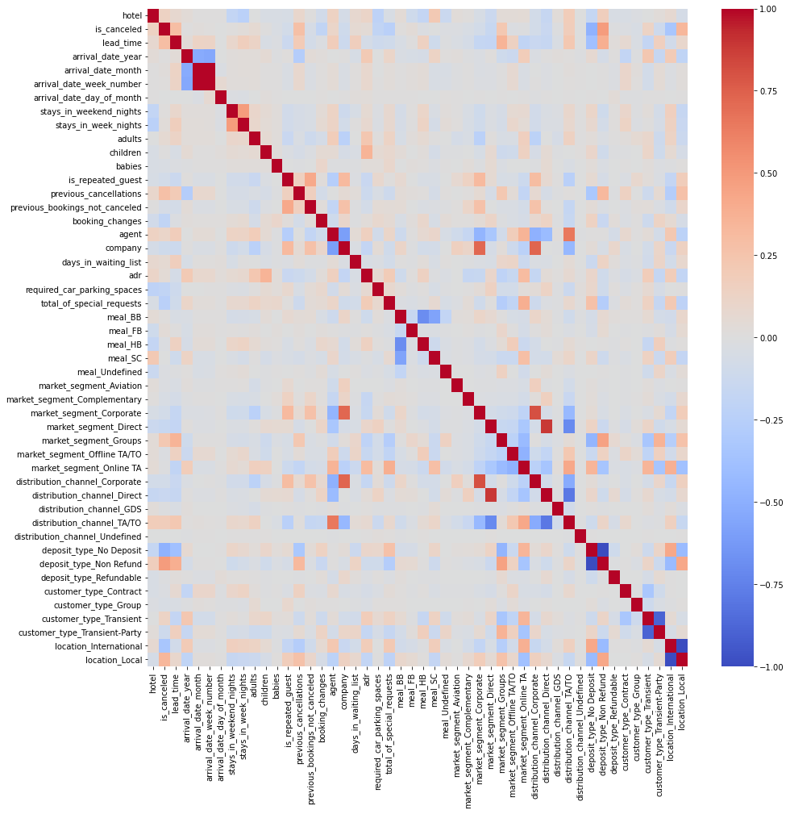

```python
#Utilizing a heatmap for visualizing the Pearson Correlation Coefficient for the testing dataset
plt.figure(figsize=(15,15))
ax=sns.heatmap(test.corr(), annot=False, cmap=sns.color_palette('coolwarm', as_cmap=True))
ax.xaxis.tick_top
plt.show()
```

```python
#looking at the Pearson Correlation Coefficient values in relation to our (y) variable for the testing dataset
test.corr()['is_canceled'].sort_values(ascending=False)
```

```
is_canceled                       1.000000
deposit_type_Non Refund           0.485994
location_Local                    0.340415
lead_time                         0.293998
previous_cancellations            0.274345
market_segment_Groups             0.224528
distribution_channel_TA/TO        0.175293
hotel                             0.138717
customer_type_Transient           0.125235
agent                             0.107187
days_in_waiting_list              0.059581
adults                            0.057008
adr                               0.044296
meal_FB                           0.036015
stays_in_week_nights              0.029045
arrival_date_month                0.015724
arrival_date_week_number          0.013686
meal_BB                           0.011313
stays_in_weekend_nights           0.008417
arrival_date_year                 0.006984
children                          0.005453
meal_SC                          -0.000352
arrival_date_day_of_month        -0.000486
distribution_channel_Undefined   -0.004024
deposit_type_Refundable          -0.009569
market_segment_Online TA         -0.015418
distribution_channel_GDS         -0.015584
meal_HB                          -0.017371
market_segment_Aviation          -0.019147
meal_Undefined                   -0.019173
market_segment_Offline TA/TO     -0.020334
customer_type_Contract           -0.021245
babies                           -0.032624
customer_type_Group              -0.039702
market_segment_Complementary     -0.039850
previous_bookings_not_canceled   -0.060395
distribution_channel_Corporate   -0.078694
market_segment_Corporate         -0.083715
is_repeated_guest                -0.085140
company                          -0.107904
customer_type_Transient-Party    -0.116920
distribution_channel_Direct      -0.148353
market_segment_Direct            -0.152161
booking_changes                  -0.189182
required_car_parking_spaces      -0.192539
total_of_special_requests        -0.240648
location_International           -0.340415
deposit_type_No Deposit          -0.482182
Name: is_canceled, dtype: float64
```

```python
#Calculating the Pearson Correlation Coefficient for the training dataset
#distribution_channel_undefined was returning NaN because we can't divide by zero so I fill the NaN's with 0's (no correlation)
train.corr().fillna(0)
```

|  | hotel | is_canceled | lead_time | arrival_date_year | arrival_date_month | arrival_date_week_number | arrival_date_day_of_month | stays_in_weekend_nights | stays_in_week_nights | adults | ... | distribution_channel_Undefined | deposit_type_No Deposit | deposit_type_Non Refund | deposit_type_Refundable | customer_type_Contract | customer_type_Group | customer_type_Transient | customer_type_Transient-Party | location_International | location_Local |
| --- | --- | --- | --- | --- | --- | --- | --- | --- | --- | --- | --- | --- | --- | --- | --- | --- | --- | --- | --- | --- | --- |
| hotel | 1.000000 | 0.136566 | 0.076983 | 0.033772 | 0.000739 | 0.000110 | -0.003053 | -0.189335 | -0.238544 | -0.007433 | ... | 0.0 | -0.168588 | 0.173862 | -0.041664 | -0.039926 | -0.026198 | -0.005902 | 0.028547 | 0.054730 | -0.054730 |
| is_canceled | 0.136566 | 1.000000 | 0.292638 | 0.020631 | 0.009188 | 0.005988 | -0.008163 | -0.005513 | 0.023807 | 0.059643 | ... | 0.0 | -0.476934 | 0.480375 | -0.012188 | -0.024700 | -0.038498 | 0.136748 | -0.127549 | -0.329663 | 0.329663 |
| lead_time | 0.076983 | 0.292638 | 1.000000 | 0.041691 | 0.132674 | 0.128263 | 0.004376 | 0.084870 | 0.164925 | 0.119546 | ... | 0.0 | -0.379718 | 0.379627 | 0.016352 | 0.068964 | -0.029338 | -0.174745 | 0.159900 | -0.084825 | 0.084825 |
| arrival_date_year | 0.033772 | 0.020631 | 0.041691 | 1.000000 | -0.527796 | -0.540450 | 0.001324 | 0.022430 | 0.031890 | 0.032302 | ... | 0.0 | 0.064130 | -0.064286 | -0.001189 | -0.168175 | -0.008760 | 0.226669 | -0.164317 | 0.193132 | -0.193132 |
| arrival_date_month | 0.000739 | 0.009188 | 0.132674 | -0.527796 | 1.000000 | 0.995093 | -0.026046 | 0.018835 | 0.016799 | 0.029008 | ... | 0.0 | -0.007175 | 0.009304 | -0.019304 | 0.089292 | 0.009525 | -0.078927 | 0.042428 | -0.024449 | 0.024449 |
| arrival_date_week_number | 0.000110 | 0.005988 | 0.128263 | -0.540450 | 0.995093 | 1.000000 | 0.066943 | 0.018687 | 0.013052 | 0.026448 | ... | 0.0 | -0.006524 | 0.008281 | -0.015917 | 0.087913 | 0.009756 | -0.079076 | 0.043159 | -0.026058 | 0.026058 |
| arrival_date_day_of_month | -0.003053 | -0.008163 | 0.004376 | 0.001324 | -0.026046 | 0.066943 | 1.000000 | -0.015005 | -0.028868 | -0.000025 | ... | 0.0 | 0.005677 | -0.009000 | 0.030364 | -0.012578 | 0.002408 | -0.002304 | 0.007626 | -0.004293 | 0.004293 |
| stays_in_weekend_nights | -0.189335 | -0.005513 | 0.084870 | 0.022430 | 0.018835 | 0.018687 | -0.015005 | 1.000000 | 0.496753 | 0.094705 | ... | 0.0 | 0.117373 | -0.117778 | -0.001074 | 0.103900 | -0.007298 | 0.017170 | -0.063191 | 0.158811 | -0.158811 |
| stays_in_week_nights | -0.238544 | 0.023807 | 0.164925 | 0.031890 | 0.016799 | 0.013052 | -0.028868 | 0.496753 | 1.000000 | 0.099396 | ... | 0.0 | 0.080440 | -0.081316 | 0.004780 | 0.135616 | -0.015864 | 0.008473 | -0.066589 | 0.141961 | -0.141961 |
| adults | -0.007433 | 0.059643 | 0.119546 | 0.032302 | 0.029008 | 0.026448 | -0.000025 | 0.094705 | 0.099396 | 1.000000 | ... | 0.0 | 0.037034 | -0.037488 | 0.002666 | 0.019474 | 0.061833 | 0.093271 | -0.118351 | 0.131371 | -0.131371 |
| children | -0.054292 | 0.004613 | -0.039578 | 0.056118 | 0.007944 | 0.007440 | 0.009525 | 0.046138 | 0.045876 | 0.061091 | ... | 0.0 | 0.095478 | -0.095283 | -0.005696 | -0.019450 | -0.007113 | 0.100627 | -0.096951 | 0.069088 | -0.069088 |
| babies | -0.044701 | -0.032666 | -0.021764 | -0.012542 | 0.013167 | 0.013078 | -0.001965 | 0.018221 | 0.020674 | 0.018207 | ... | 0.0 | 0.031611 | -0.031426 | -0.002998 | -0.001720 | 0.001306 | 0.022465 | -0.023311 | -0.006040 | 0.006040 |
| is_repeated_guest | -0.054261 | -0.083152 | -0.122161 | 0.010302 | -0.028904 | -0.028407 | -0.007274 | -0.083738 | -0.096345 | -0.143079 | ... | 0.0 | 0.058531 | -0.058936 | 0.001343 | -0.024878 | 0.106307 | 0.021937 | -0.030561 | -0.158135 | 0.158135 |
| previous_cancellations | 0.082931 | 0.269956 | 0.209067 | -0.270823 | 0.085389 | 0.084773 | -0.013846 | -0.053215 | -0.057431 | -0.035299 | ... | 0.0 | -0.318473 | 0.320816 | -0.008555 | 0.141083 | -0.007112 | -0.108196 | 0.053331 | -0.264743 | 0.264743 |
| previous_bookings_not_canceled | -0.006943 | -0.056145 | -0.073345 | 0.026441 | -0.019760 | -0.018902 | 0.000582 | -0.043376 | -0.050875 | -0.110286 | ... | 0.0 | 0.032167 | -0.032000 | -0.002850 | -0.016961 | 0.024286 | 0.030328 | -0.028842 | -0.099690 | 0.099690 |
| booking_changes | -0.087467 | -0.184912 | -0.008222 | 0.022362 | 0.004082 | 0.005040 | 0.011617 | 0.039427 | 0.064239 | -0.066770 | ... | 0.0 | 0.142583 | -0.146503 | 0.030255 | -0.027958 | 0.010052 | -0.112666 | 0.130315 | 0.067655 | -0.067655 |
| agent | 0.141580 | 0.100223 | 0.180756 | 0.001219 | 0.030217 | 0.028378 | -0.004631 | 0.125214 | 0.119047 | 0.190365 | ... | 0.0 | 0.014908 | -0.008742 | -0.057370 | 0.073447 | -0.011723 | 0.027048 | -0.059367 | 0.228563 | -0.228563 |
| company | -0.062281 | -0.096295 | -0.126466 | -0.005019 | -0.023281 | -0.022100 | -0.004465 | -0.107366 | -0.083162 | -0.242112 | ... | 0.0 | 0.023044 | -0.032028 | 0.081776 | -0.044985 | 0.013116 | -0.079128 | 0.101756 | -0.136090 | 0.136090 |
| days_in_waiting_list | 0.073227 | 0.052152 | 0.170324 | -0.057490 | 0.022717 | 0.026648 | 0.022920 | -0.054931 | -0.004044 | -0.010335 | ... | 0.0 | -0.117259 | 0.116317 | 0.013469 | -0.024136 | -0.007252 | -0.101353 | 0.119589 | -0.080588 | 0.080588 |
| adr | 0.100773 | 0.049145 | -0.067785 | 0.208914 | 0.084691 | 0.080887 | 0.031043 | 0.051551 | 0.070187 | 0.236558 | ... | 0.0 | 0.097586 | -0.095961 | -0.018949 | -0.056602 | -0.026646 | 0.185944 | -0.167631 | 0.173091 | -0.173091 |
| required_car_parking_spaces | -0.218934 | -0.197296 | -0.119327 | -0.016437 | 0.000888 | 0.002773 | 0.010187 | -0.018977 | -0.025480 | 0.013863 | ... | 0.0 | 0.094428 | -0.095791 | 0.008689 | -0.019933 | 0.006289 | 0.067356 | -0.063726 | -0.011376 | 0.011376 |
| total_of_special_requests | -0.045434 | -0.233032 | -0.095733 | 0.109274 | 0.027931 | 0.026055 | 0.003176 | 0.074026 | 0.066545 | 0.128788 | ... | 0.0 | 0.269092 | -0.268190 | -0.019302 | 0.038801 | 0.005962 | 0.131695 | -0.158103 | 0.212277 | -0.212277 |
| meal_BB | 0.040281 | 0.013243 | -0.038973 | -0.031228 | -0.004639 | -0.002042 | 0.009723 | -0.065557 | -0.062126 | -0.036013 | ... | 0.0 | -0.074969 | 0.073551 | 0.016124 | 0.010120 | 0.019065 | 0.068004 | -0.079987 | -0.082259 | 0.082259 |
| meal_FB | -0.104832 | 0.040048 | 0.012097 | -0.060278 | 0.022608 | 0.022110 | -0.004204 | 0.018954 | 0.019168 | 0.011975 | ... | 0.0 | -0.062950 | 0.063548 | -0.002929 | -0.013760 | -0.003695 | -0.011735 | 0.019217 | -0.058424 | 0.058424 |
| meal_HB | -0.172866 | -0.021129 | 0.133967 | -0.057706 | 0.040628 | 0.038859 | -0.005944 | 0.105175 | 0.121602 | 0.041889 | ... | 0.0 | 0.009599 | -0.008312 | -0.012235 | 0.018011 | -0.014717 | -0.171987 | 0.177117 | -0.014376 | 0.014376 |
| meal_SC | 0.217221 | 0.003286 | -0.094212 | 0.127440 | -0.037849 | -0.039949 | -0.010152 | -0.037890 | -0.064566 | 0.003923 | ... | 0.0 | 0.116569 | -0.116259 | -0.007619 | -0.027470 | -0.008879 | 0.133866 | -0.128367 | 0.167584 | -0.167584 |
| meal_Undefined | -0.139857 | -0.028934 | -0.015903 | 0.005365 | -0.024201 | -0.022898 | 0.011209 | 0.024029 | 0.031968 | -0.006988 | ... | 0.0 | 0.001899 | -0.001522 | -0.003549 | -0.011907 | -0.003545 | -0.096568 | 0.108430 | -0.038950 | 0.038950 |
| market_segment_Aviation | 0.032429 | -0.011708 | -0.042504 | 0.018651 | -0.003613 | -0.003469 | -0.001801 | 0.008679 | -0.002566 | -0.067943 | ... | 0.0 | 0.017172 | -0.017072 | -0.001629 | -0.008555 | 0.004288 | 0.016494 | -0.014444 | -0.002633 | 0.002633 |
| market_segment_Complementary | 0.009711 | -0.040598 | -0.067944 | -0.010782 | 0.008106 | 0.008155 | -0.001667 | -0.045232 | -0.049591 | -0.047590 | ... | 0.0 | 0.029602 | -0.029429 | -0.002808 | -0.013900 | 0.003195 | 0.035665 | -0.032231 | -0.079494 | 0.079494 |
| market_segment_Corporate | -0.044496 | -0.080806 | -0.163424 | -0.025560 | -0.017795 | -0.016146 | -0.003628 | -0.107440 | -0.097634 | -0.239046 | ... | 0.0 | 0.036216 | -0.035907 | -0.004331 | -0.035198 | 0.004994 | -0.037581 | 0.054694 | -0.171620 | 0.171620 |
| market_segment_Direct | -0.134116 | -0.155531 | -0.174500 | 0.013176 | -0.017748 | -0.017198 | 0.007539 | -0.024278 | -0.026519 | 0.012610 | ... | 0.0 | 0.127756 | -0.127460 | -0.007950 | -0.062771 | 0.031073 | 0.119760 | -0.104579 | -0.044995 | 0.044995 |
| market_segment_Groups | 0.042800 | 0.221358 | 0.343263 | -0.107755 | 0.003295 | 0.003859 | 0.014253 | -0.062911 | -0.070878 | -0.052507 | ... | 0.0 | -0.472066 | 0.467444 | 0.061841 | 0.006863 | -0.024183 | -0.333098 | 0.354752 | -0.265569 | 0.265569 |
| market_segment_Offline TA/TO | 0.027042 | -0.032248 | 0.147375 | -0.122333 | 0.067861 | 0.068185 | -0.012854 | 0.067999 | 0.096353 | -0.036128 | ... | 0.0 | -0.124823 | 0.127062 | -0.015511 | 0.112925 | 0.026816 | -0.200608 | 0.158114 | -0.089113 | 0.089113 |
| market_segment_Online TA | 0.042858 | -0.002547 | -0.185598 | 0.181261 | -0.039838 | -0.041555 | -0.003019 | 0.057384 | 0.039555 | 0.171973 | ... | 0.0 | 0.352739 | -0.351442 | -0.026353 | -0.039986 | -0.025701 | 0.344421 | -0.343432 | 0.380603 | -0.380603 |
| distribution_channel_Corporate | -0.078667 | -0.074307 | -0.131673 | -0.031101 | 0.010250 | 0.010943 | -0.015893 | -0.086071 | -0.088174 | -0.231964 | ... | 0.0 | 0.029122 | -0.028633 | -0.005693 | -0.039871 | 0.001607 | -0.073339 | 0.095320 | -0.141709 | 0.141709 |
| distribution_channel_Direct | -0.160374 | -0.153051 | -0.163544 | -0.000540 | -0.016721 | -0.015157 | 0.016250 | -0.036958 | -0.026415 | -0.007018 | ... | 0.0 | 0.103745 | -0.109438 | 0.048178 | -0.068177 | 0.018344 | 0.084307 | -0.062340 | -0.072210 | 0.072210 |
| distribution_channel_GDS | 0.028427 | -0.014652 | -0.031358 | 0.014567 | -0.003704 | -0.003262 | -0.000569 | -0.011229 | -0.022847 | -0.053368 | ... | 0.0 | 0.015053 | -0.014965 | -0.001428 | -0.007499 | -0.002823 | 0.023014 | -0.020610 | 0.024234 | -0.024234 |
| distribution_channel_TA/TO | 0.180981 | 0.176605 | 0.221461 | 0.017461 | 0.008579 | 0.006783 | -0.004372 | 0.084000 | 0.077447 | 0.149631 | ... | 0.0 | -0.107595 | 0.112162 | -0.037651 | 0.082801 | -0.016346 | -0.030813 | -0.001303 | 0.143571 | -0.143571 |
| distribution_channel_Undefined | 0.000000 | 0.000000 | 0.000000 | 0.000000 | 0.000000 | 0.000000 | 0.000000 | 0.000000 | 0.000000 | 0.000000 | ... | 0.0 | 0.000000 | 0.000000 | 0.000000 | 0.000000 | 0.000000 | 0.000000 | 0.000000 | 0.000000 | 0.000000 |
| deposit_type_No Deposit | -0.168588 | -0.476934 | -0.379718 | 0.064130 | -0.007175 | -0.006524 | 0.005677 | 0.117373 | 0.080440 | 0.037034 | ... | 0.0 | 1.000000 | -0.994137 | -0.094843 | -0.007026 | 0.022423 | -0.109353 | 0.115352 | 0.423429 | -0.423429 |
| deposit_type_Non Refund | 0.173862 | 0.480375 | 0.379627 | -0.064286 | 0.009304 | 0.008281 | -0.009000 | -0.117778 | -0.081316 | -0.037488 | ... | 0.0 | -0.994137 | 1.000000 | -0.013358 | 0.007583 | -0.026415 | 0.115561 | -0.121501 | -0.426390 | 0.426390 |
| deposit_type_Refundable | -0.041664 | -0.012188 | 0.016352 | -0.001189 | -0.019304 | -0.015917 | 0.030364 | -0.001074 | 0.004780 | 0.002666 | ... | 0.0 | -0.094843 | -0.013358 | 1.000000 | -0.004835 | 0.035835 | -0.052686 | 0.051903 | 0.009964 | -0.009964 |
| customer_type_Contract | -0.039926 | -0.024700 | 0.068964 | -0.168175 | 0.089292 | 0.087913 | -0.012578 | 0.103900 | 0.135616 | 0.019474 | ... | 0.0 | -0.007026 | 0.007583 | -0.004835 | 1.000000 | -0.013237 | -0.325854 | -0.096633 | 0.002487 | -0.002487 |
| customer_type_Group | -0.026198 | -0.038498 | -0.029338 | -0.008760 | 0.009525 | 0.009756 | 0.002408 | -0.007298 | -0.015864 | 0.061833 | ... | 0.0 | 0.022423 | -0.026415 | 0.035835 | -0.013237 | 1.000000 | -0.122675 | -0.036380 | -0.003229 | 0.003229 |
| customer_type_Transient | -0.005902 | 0.136748 | -0.174745 | 0.226669 | -0.078927 | -0.079076 | -0.002304 | 0.017170 | 0.008473 | 0.093271 | ... | 0.0 | -0.109353 | 0.115561 | -0.052686 | -0.325854 | -0.122675 | 1.000000 | -0.895528 | 0.050319 | -0.050319 |
| customer_type_Transient-Party | 0.028547 | -0.127549 | 0.159900 | -0.164317 | 0.042428 | 0.043159 | 0.007626 | -0.063191 | -0.066589 | -0.118351 | ... | 0.0 | 0.115352 | -0.121501 | 0.051903 | -0.096633 | -0.036380 | -0.895528 | 1.000000 | -0.053971 | 0.053971 |
| location_International | 0.054730 | -0.329663 | -0.084825 | 0.193132 | -0.024449 | -0.026058 | -0.004293 | 0.158811 | 0.141961 | 0.131371 | ... | 0.0 | 0.423429 | -0.426390 | 0.009964 | 0.002487 | -0.003229 | 0.050319 | -0.053971 | 1.000000 | -1.000000 |
| location_Local | -0.054730 | 0.329663 | 0.084825 | -0.193132 | 0.024449 | 0.026058 | 0.004293 | -0.158811 | -0.141961 | -0.131371 | ... | 0.0 | -0.423429 | 0.426390 | -0.009964 | -0.002487 | 0.003229 | -0.050319 | 0.053971 | -1.000000 | 1.000000 |

48 rows × 48 columns

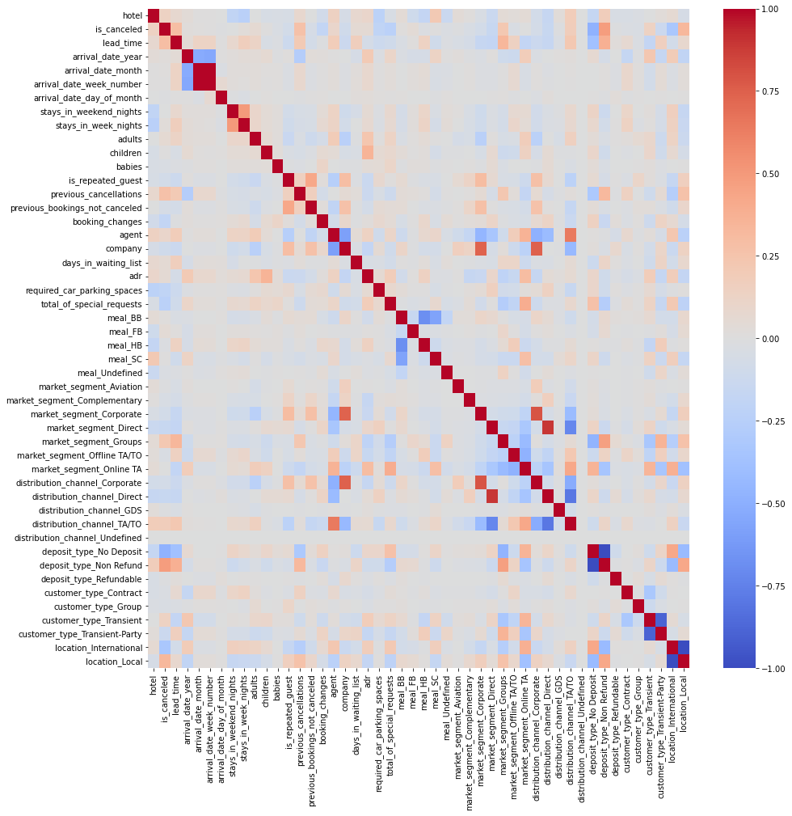

```python
#Utilizing a heatmap for visualizing the Pearson Correlation Coefficient for the training dataset
#distribution_channel_undefined was returning NaN because we can't divide by zero so I fill the NaN's with 0's (no correlation)
plt.figure(figsize=(15,15))
ax=sns.heatmap(train.corr().fillna(0), annot=False, cmap=sns.color_palette('coolwarm', as_cmap=True))
ax.xaxis.tick_top
plt.show()
```

```python
#looking at the Pearson Correlation Coefficient values in relation to our (y) variable for the training dataset
train.corr().fillna(0)['is_canceled'].sort_values(ascending=False)
```

```
is_canceled                       1.000000
deposit_type_Non Refund           0.480375
location_Local                    0.329663
lead_time                         0.292638
previous_cancellations            0.269956
market_segment_Groups             0.221358
distribution_channel_TA/TO        0.176605
customer_type_Transient           0.136748
hotel                             0.136566
agent                             0.100223
adults                            0.059643
days_in_waiting_list              0.052152
adr                               0.049145
meal_FB                           0.040048
stays_in_week_nights              0.023807
arrival_date_year                 0.020631
meal_BB                           0.013243
arrival_date_month                0.009188
arrival_date_week_number          0.005988
children                          0.004613
meal_SC                           0.003286
distribution_channel_Undefined    0.000000
market_segment_Online TA         -0.002547
stays_in_weekend_nights          -0.005513
arrival_date_day_of_month        -0.008163
market_segment_Aviation          -0.011708
deposit_type_Refundable          -0.012188
distribution_channel_GDS         -0.014652
meal_HB                          -0.021129
customer_type_Contract           -0.024700
meal_Undefined                   -0.028934
market_segment_Offline TA/TO     -0.032248
babies                           -0.032666
customer_type_Group              -0.038498
market_segment_Complementary     -0.040598
previous_bookings_not_canceled   -0.056145
distribution_channel_Corporate   -0.074307
market_segment_Corporate         -0.080806
is_repeated_guest                -0.083152
company                          -0.096295
customer_type_Transient-Party    -0.127549
distribution_channel_Direct      -0.153051
market_segment_Direct            -0.155531
booking_changes                  -0.184912
required_car_parking_spaces      -0.197296
total_of_special_requests        -0.233032
location_International           -0.329663
deposit_type_No Deposit          -0.476934
Name: is_canceled, dtype: float64
```

## Machine Learning Model

I have chosen to implement a **Decision Tree Classifier** machine learning model.

**My thought process for model selection:**  
**1) Categorical or Numerical:** The categorical nature of the (y) variable led me to choose a model within the Supervised Learning-Classification subset of machine learning model options.  
**2) Algorithm — space and time complexity:** For a time sensitive project, we can't afford to wait long amounts of time for model iterations and testing.  
**3) Dataset Size:** Which wasn't a concern for this assessment since the dataset is quite small.  
**4) Explainability:** A decision tree classifier can be explained to both a non-technical and technical audience.

Normally, I would have selected three to four models from the Supervised Learning-Classification subset of machine learning models. For example, Logistic Regression (classic choice), Support Vector Machine (SVM), Decision Tree Classifier, and Random Forest Classifier. In this way, I could compare results across models and choose the one with the optimal outcome given the application. Also, I would request a colleague to perform some due diligence testing on my models.

**The model takes two forms:**  
1) Raw  
2) Optimized

I did this so I could compare the baseline results provided by the raw model with the improved results provided by the optimized model.

The **Hyperparameters** in my optimized model include: maximum depth, maximum features, minimum leaf samples, and minimum leaf sample splits. These serve to constrain the model which provides a boost in overall performance. It's especially common for tree depth, node samples, and node sample splits to become large which leads to variance/overfitting. As can be observed in the comments, I ran the hyperparameters with various values while calling the dt.best*params* method to arrive at an acceptable selection for use in the optimized model. The hyperparameters were used within the **GridSearchCV** method which performs a rather exhaustive combinatorial search over five-folds. The downside to Grid Search is the exponential growth that comes with adding too many hyperparameters.

**Regularization** aims to reduce the complexity of models by introducing a penalty term with the goal of reducing variance/overfitting. A traditional example might include a Regression model regularized with either Lasso, Ridge, or Elastic net (a combination of Lasso and Ridge).  
Unfortunately, it’s not that straight forward for our Decision Tree Classifier Model.  
That said, the complexity of our Decision Tree Classifier Model can be constrained by using our hyperparameters (maximum depth, maximum features, minimum leaf samples, and minimum leaf sample splits) which ultimately acts a pseudo-regularization parameter for reducing variance/overfitting.

With this in mind, we can effortlessly observe the work of our hyperparameters by performing a visual inspection of the tree structures for both models.  
**The top visual represents the raw model** while **the bottom visual represents the optimized model**.  
We are not concerned with the details of these visuals; but rather, the overall structural reduction observed between the top visual and the bottom visual.  
This is what reducing variance/overfitting looks like.

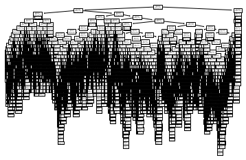

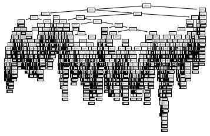

I used **K-Fold Cross-Validation** to avoid training and testing on the same subsets of data which could have led to variance/overfitting. We can confirm success by observing the nearly similar scores recorded for cross-validation and accuracy in the optimized model results.  
**K-Fold Cross-Validation requires three steps:**  
1) A random shuffle of equal size folds.  
2) for each fold (k), train the model on all the other folds except for (i) and evaluate the validation error using fold (i).  
3) Compute the average of the (k) validation errors from step 2 to get an estimate of the actual error.  
*k = training data* , *i = testing data*

**What could we do to further improve the Model?**  
• Normalize the data.  
• Feature selection via pruning or forward/backward stepwise algorithm.  
• Continue refining the hyperparameters.  
• Use the ROC curve/AUC performance measurements for further insight (note: The Receiver Operating Characteristic (ROC) curve plots the true positive rate Vs. the false positive rate. The Area Under the Curve (AUC) measures how well the classification model separates classes).  
• Train three to four model in parallel to learn more about performance and the dataset.

```python
#our Raw Model
from sklearn.tree import DecisionTreeClassifier
from sklearn.metrics import accuracy_score, precision_score, recall_score, f1_score


dt_raw = DecisionTreeClassifier()
dt = dt_raw.fit(x_train,y_train)
predicting_y = dt.predict(x_test)

#from sklearn import tree
#tree.plot_tree(dt)
```

```python
#accuracy=(tp+tn)/(tp+tn+fp+fn)
#precision=(tp)/(tp + fp)
#recall=(tp)/(tp+fn) (also called sensitivity)
#f1=2*((precision*recall)/(precision+recall)) (also known as the harmonic mean of precision recall)
print('Raw Model: Testing Results')
print('--------------------------')
print('Accuracy: {:.2%}'.format(accuracy_score(y_test, predicting_y)))
print('Precision: {:.2%}'.format(precision_score(y_test, predicting_y)))
print('Recall: {:.2%}'.format(recall_score(y_test, predicting_y)))
print('F1-Score: {:.2%}'.format(f1_score(y_test, predicting_y)))
```

```
Raw Model: Testing Results
--------------------------
Accuracy: 84.76%
Precision: 78.31%
Recall: 80.77%
F1-Score: 79.52%
```

```python
print('Raw Model: Training Vs. Testing')
print('-------------------------------')
print('Training Result: {:.2%}'.format(dt.score(x_train, y_train)))
print('Testing Result: {:.2%}'.format(dt.score(x_test, y_test)))
```

```
Raw Model: Training Vs. Testing
-------------------------------
Training Result: 99.53%
Testing Result: 84.76%
```

```python
#building our Optimized Model
from sklearn.tree import DecisionTreeClassifier
from sklearn.model_selection import GridSearchCV, cross_val_score, StratifiedKFold
from sklearn.metrics import accuracy_score, precision_score, recall_score, f1_score

#fine-tuning the hyperparameters over several iterations with different values...
#Observing how this changes our performance mesures. I'm looking for the best parameters.
#hyperparameters = {'max_depth': [30,50], 'max_features': [0.5, 0.7], min_samples_leaf': [1,10], 'min_samples_split': [50,100]}
#dt.best_params_
#{'max_depth': 50,
# 'max_features': 0.7,
# 'min_samples_leaf': 10,
# 'min_samples_split': 100}

hyperparameters = {'max_depth': [50], 'max_features': [0.7], 'min_samples_leaf': [10], 'min_samples_split': [100]}

dt_optimized = GridSearchCV(DecisionTreeClassifier(), hyperparameters, cv=5, scoring='accuracy')
dt = dt_optimized.fit(x_train, y_train)

predicting_y = dt.predict(x_test)

#from sklearn import tree
#tree.plot_tree(dt.best_estimator_)
```

```python
#accuracy=(tp+tn)/(tp+tn+fp+fn)
#precision=(tp)/(tp + fp)
#recall=(tp)/(tp+fn) (also called sensitivity)
#f1=2*((precision*recall)/(precision+recall)) (also known as the harmonic mean of precision recall)
print('Optimized Model: Testing Results')
print('--------------------------------')
print('Accuracy: {:.2%}'.format(accuracy_score(y_test, predicting_y)))
print('Precision: {:.2%}'.format(precision_score(y_test, predicting_y)))
print('Recall: {:.2%}'.format(recall_score(y_test, predicting_y)))
print('F1-Score: {:.2%}'.format(f1_score(y_test, predicting_y)))
print('Cross-Val: {:.2%}'.format(cross_val_score(dt.best_estimator_, X, y, cv=StratifiedKFold(shuffle=True)).mean()))
```

```
Optimized Model: Testing Results
--------------------------------
Accuracy: 84.60%
Precision: 80.08%
Recall: 77.16%
F1-Score: 78.59%
Cross-Val: 84.88%
```

```python
print('Optimized Model: Training Vs. Testing')
print('-------------------------------------')
print('Training Result: {:.2%}'.format(dt.score(x_train, y_train)))
print('Testing Result: {:.2%}'.format(dt.score(x_test, y_test)))
```

```
Optimized Model: Training Vs. Testing
-------------------------------------
Training Result: 86.87%
Testing Result: 84.60%
```

```python
from sklearn.metrics import confusion_matrix
cm = confusion_matrix(y_test, predicting_y)
#True Positive, False Negative (Type 2 Error)
#False Positive (Type 1 Error), True Negative

#False Positive=the model incorrectly predicts customer cancellation when the customer actually did not cancel
#False Negative=the model incorrectly predicts a customer did not cancel when the customer actually did cancel

#True Positive= the model correctly predicts customer cancellation
#True Negative=the model correctly predicts a customer did not cancel
```

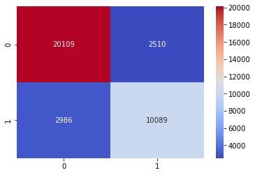

```python
sns.heatmap(cm,annot=True,fmt='d',cmap=sns.color_palette('coolwarm', as_cmap=True))
```

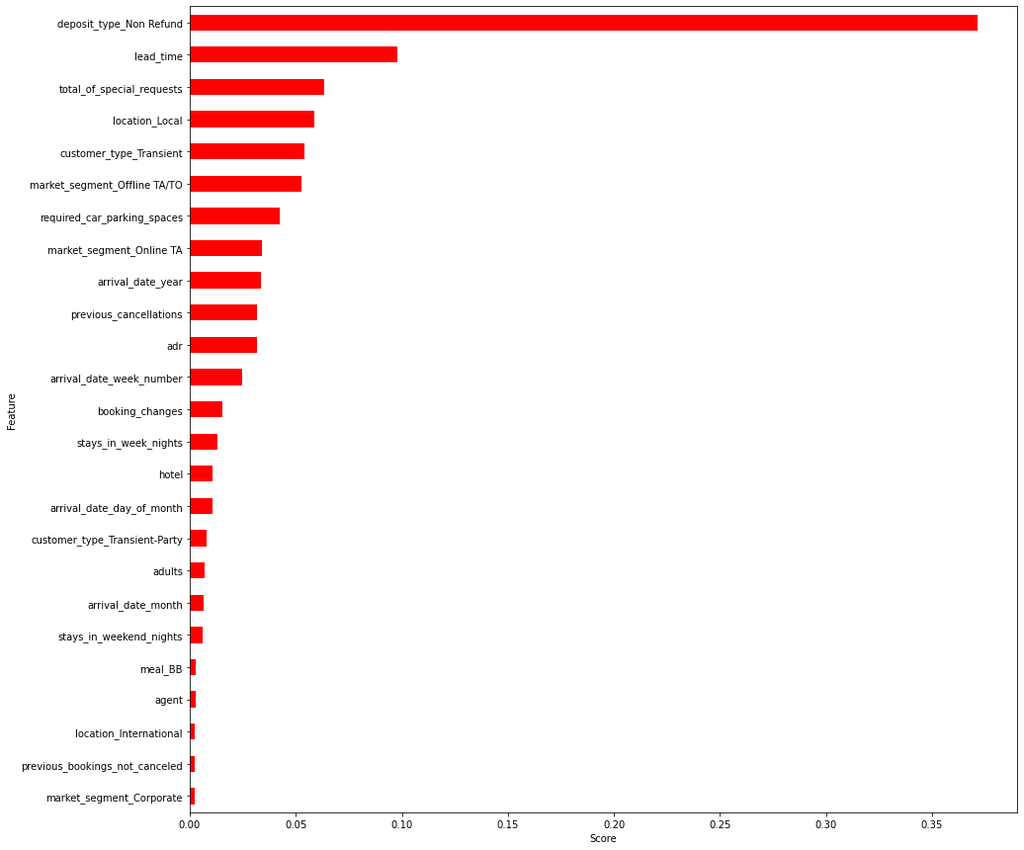

```python
#visualizing the top 25 (x) features impacting our model
barchart = (pd.Series(dt.best_estimator_.feature_importances_,index=X.columns).nlargest(25).plot(kind='barh', figsize=(15,15), color='red'))
barchart.invert_yaxis()
plt.xlabel('Score')
plt.ylabel('Feature')
```